# STA 601/360 Homework6

Jae Hyun Lee, jl914

13 October, 2019

# HW6 for STA-601

## Exercise 1

#### a)

are $\theta_A$ and $\theta_B$ independent or dependent under this prior distribution? In what situations is such a joint prior distribution justified?

$$P(\theta_B \mid \theta, \gamma) = P(\theta_B \mid \theta_A, \gamma) \quad for \; \theta = \theta_A \\
P(\theta_B \mid \theta_A, \gamma) \ne P(\theta_B \mid \gamma) = \int P(\theta_B \mid \theta,\gamma)d\theta$$
Thus we can conclude that $\theta_B$ and $\theta_A$ are dependent.

#### b)

obtain the form of the full conditional distribution of $\theta given y_A,y_B,\gamma$

$$\begin{aligned}
P(y_A \mid \theta_A) = \theta_A^{n_A \bar{y_A}} exp\{-n_A\theta_A \} \\
P(y_B \mid \theta_B) = \theta_B^{n_B \bar{y_B}} exp\{-n_B\theta_B \} \\
\end{aligned}$$
after reparamaterization,

$$\begin{aligned}
P(y_A \mid \theta, \gamma) = \theta^{n_A \bar{y_A}} exp\{-n_A\theta \} \\
P(y_B \mid \theta, \gamma) = \theta^{n_B \bar{y_B}} \gamma^{n_B \bar{y_B}} exp\{-n_B \theta \gamma\}
\end{aligned}$$
Then assuming that two samples are independent given $\theta$ and $\gamma$, their conditional joint pdf are
$$\begin{aligned}
P(y_A,y_B \mid \theta, \gamma) = \theta^{n_A\bar{y_A}+n_B\bar{y_B}} exp\{-n_A\theta - n_B\theta\gamma\}
\end{aligned}$$
Full conditional distribution for $\theta$ is
$$\begin{aligned}
P(\theta \mid y_A, y_B, \gamma) \propto P(\theta \mid \gamma)P(y_A,y_B \mid \theta, \gamma) &= P(\theta)P(y_A,y_B \mid \theta) \\
&= \theta^{n_A\bar{y_A} + n_B\bar{n_B} + a_\theta - 1} exp\{-n_A\theta -n_B\theta\gamma - b_\theta \theta\} \\
&\sim gamma(n_A\bar{y_A} + n_B\bar{n_B} + a_\theta, n_A+n_B\gamma + b_\theta)
\end{aligned}$$

#### c)

obtain the form of the full conditional distribution of $\gamma given y_A,y_B, and \theta$

$$\begin{aligned}
P(\gamma \mid y_A,y_B,\theta) &\propto P(\gamma \mid \theta)P(y_A,y_B \mid \theta,\gamma) \\
&\propto \gamma^{n_B\bar{y_B} + a_\gamma -1} exp\{n_B\theta + b_\gamma\} \\
&\sim gamma(n_B\bar{y_B} + a_\gamma, n_B\theta + b_\gamma)
\end{aligned}$$

#### d)

```r
bach <- read.delim("menchild30bach.dat",sep = " ")
Y_A <- bach %>%
  unlist %>%
  na.omit
nobach <- read.delim("menchild30nobach.dat",sep = " ")
Y_B <- nobach %>%
  unlist %>%
  na.omit
print(c(length(Y_A),sum(Y_A)))
```

```
## [1] 20 18
```

```r
print(c(length(Y_B),sum(Y_B)))
```

```
## [1] 181 249
```

```r
set.seed(1000)
prior_t <- c(2,1)
prior_g <- matrix(rep(2^(3:7),2),ncol = 2)
stat_A <- c(length(Y_A),sum(Y_A))
stat_B <- c(length(Y_B),sum(Y_B))
theta <- matrix(rep(c(1,rep(NA,10000)),5), ncol = 5)
gamma <- matrix(rep(c(1,rep(NA,10000)),5), ncol = 5)

for(j in 1:5){
  for(i in 1:10000){
    theta[i+1,j] <- rgamma(1, stat_A[2] + stat_B[2] + prior_t[1],
                       stat_A[1] + stat_B[1]*gamma[i] + prior_t[2])
    gamma[i+1,j] <- rgamma(1, stat_B[2] + prior_g[j,1], stat_B[1]*theta[i+1] + prior_g[j,2])
  }
}

theta_A <- theta[5001:10000,] #burn in period is 1:5000
theta_B <- (theta * gamma)[5001:10000,] #burn in period is 1:5000

apply(theta_B - theta_A, 2, mean)
```

```
## [1] 0.2739666 0.2686124 0.2481954 0.2123776 0.1689382
```

As prior parameter for $\gamma$ increases, the average difference between $\theta_B - \theta_A$ decreases. We have set that $\gamma = \theta_B/\theta_A$ and prior parameter $a_\gamma = b_\gamma$ so that mean for $\gamma = a_\gamma / b_\gamma = 1$. That is the prior information which support that the relative of $\theta_B$ and $\theta_A$ gets stronger. As a result, the average difference of $\theta_B$ and $\theta_A$ becomes smaller because the prior information that support $\theta_B = \theta_A$ becomes stronger.

## Exercise 2

#### a)

obtain the full conditional distribution for $\beta$.

From given information about Z, Y, $\beta$ and c, we can know that

$$\begin{aligned}
&P(\mathbf{z} \mid \beta, \mathbf{x}) \sim iid \; N(\beta\mathbf{x}, 1) \\
\rightarrow &P(Z_1 \cdot\cdot\cdot Z_n \mid \beta\mathbf{x}) = (2\pi)^{-n/2}exp\{\frac{\sum_{i=1}^{n}(Z_i - \beta x_i)^2}{2}\}
\end{aligned}$$
$$\begin{aligned}
P(Y_i \mid Z_i,c) = 1 \quad if \; Z_i >c \\
P(Y_i \mid Z_i,c) = 0 \quad if \; Z_i <c
\end{aligned}$$
Obviously, we can know that

$$P(\beta \mid \mathbf{y,x,z},c) \propto P(\mathbf{y} \mid \beta, \mathbf{x,z},c) P(\mathbf{z} \mid \beta, \mathbf{x}, c)P(\beta \mid \mathbf{x},c)$$
Since, y does not directly depend on $\beta$ and $\mathbf{x}$ and does indirectly depend through $\mathbf{z}$, we can conclude that $P(\mathbf{y} \mid \beta, \mathbf{x,z},c)$ = $P(\mathbf{y} \mid \mathbf{z},c)$. In addition, $P(\beta \mid \mathbf{x},c) = P(\beta)$ because of assumed independence between prior.
$$\begin{aligned}
P(\beta \mid \mathbf{x,y,z},c) &\propto P(\mathbf{z} \mid \mathbf{x},\beta,c)P(\beta \mid \mathbf{x},c) \\
&= P(\mathbf{z} \mid \mathbf{x},\beta,c)P(\beta) \\
&\propto exp\{-\frac{1}{2}[\sum_{i=1}^n x_i^2 \beta^2 -2\beta\sum_{i=1}^n x_iz_i]\}exp\{-\frac{\beta^2}{2\tau_\beta^2}\} \\
&= exp\{-\frac{\beta^2}{2}[\frac{1}{\tau_\beta^2} + \sum_{i=1}^n x_i ^2] + \beta \sum_{i=1}^n x_iz_i\} \quad which \; is \; kernal \; of \; normal \;distribution \\
&\sim N(\tau_{\beta_n}^2 \sum_{i=1}^{n} x_iz_i, \tau_{\beta_n}^2) \quad where \quad \tau_{\beta_n}^2 = [\frac{1}{\tau_\beta^2} + \sum_{i=1}^n x_i^2]^{-1}
\end{aligned}$$

Thus full conditional distribution for $\beta$, $P(\beta \mid \mathbf{y,x,z},c)$ is pdf of $N(\tau_{\beta_n}^2 \sum_{i=1}^{n} x_i, \tau_{\beta_n}^2) \quad where \quad \tau_{\beta_n}^2 = [\frac{1}{\tau_\beta^2} + \sum_{i=1}^n x_i^2]^{-1}$

#### b)

show that full conditional distributin of c is constrained normal density. Similarly show that full conditional distribution of $z_i$ is proportional to a normal density but constrained to be either above c or below C depending on y_i

First, we have to obtain full conditional distribution of c

$$\begin{aligned}
P(c \mid \mathbf{x,y,z}, \beta) \propto P(\mathbf{y} \mid \mathbf{x,z},\beta,c) P(c \mid \mathbf{x,z}, \beta)
\end{aligned}$$
$$\begin{aligned}
P(y_i = 0 \mid x_i, z_i, c, \beta) = P(z_i < c \mid x_i,\beta,c) \\
P(y_i = 1 \mid x_i, z_i, c, \beta) = P(z_i > c \mid x_i,\beta,c) \\
\end{aligned}$$
Let k be $\sum y_i$ where $0 \le k \le n$ and since $z_i$ are conditionally independent given $x_i,\beta$, by de Finetti’s theorem, $z_i$ are exchangable. Thus even if we change the order of $z_i$, their joint pdf is same as before. Let we arrange $z_i$ so that $z_i \le z_j$ for $i > j$. Then joint pdf of $y_i$ is
$$\begin{aligned}
P(\mathbf{y} \mid \mathbf{x,z}, \beta,c) = P(z_1 \cdot\cdot\cdot z_k >c, z_{k+1} \cdot\cdot\cdot z_n <c \mid \mathbf{x},c,\beta)
\end{aligned}$$
Moreover, we know that $z_k$ is min value of $z_i$ which satisfy $y_i = 1$, whereas $z_{k+1}$ is max value of $z_j$ which satisfy $y_j = 0$. Now we also know that $P(c \mid \mathbf{x,z},\beta) = P(c)$ because the likelihood function of $z_i$ does not depend on c. Thus

$$\begin{aligned}
p(c \mid \mathbf{y,x,z}, \beta) &\propto P(\mathbf{y} \mid \mathbf{x,z},c,\beta)P(c \mid \mathbf{x,z}, \beta) \\
&= P(z_n \cdot\cdot\cdot z_{k+1}< c < z_k \cdot\cdot\cdot z_1 \mid \mathbf{x},\beta,c)P(c) \\
&= P(z_{k+1} <c<z_k \mid \mathbf{x},\beta,c)P(c)
\end{aligned}$$
Since, $z_i$ are normal distribtion for mean $\beta x_i$ with variance 1, we can rewrite $P(z_{k+1} <c<z_k \mid \mathbf{x},\beta,c)$ as $\Phi(z_k - x_k\beta) - \Phi(z_{k+1} - x_k\beta)$ where $\Phi$ is CDF of standard normal distribution. tt

As a result, the full conditional distribution for c are constrained normal between $z_{k+1}$ and $z_k$

Similarly, $P(z_i \mid \mathbf{x,y,z_{-i}}, \beta, c)$ is constrained normal. Since, $z_i$ are conditionally independent, $P(z_i \mid \mathbf{x,y,z_{-i}},\beta,c) = P(z_i \mid \mathbf{x,y},\beta,c)$
$$\begin{aligned}
P(z_i \mid x_i, y_i = 0, \beta, c) &\propto P(y_i = 0 \mid z_i,c)P(z_i \mid \beta, x_i,c)\\
&= P(z_i<c \mid x_i,\beta,c)P(z_i \mid \beta,x_i,c) \\
&= \Phi(c - \beta x_i)P(z_i)
\end{aligned}$$
As above equation, when $y_i = 0$, the distribution of $P(z_i \mid y_i, \beta, c, x_i) \sim trancate Normal (\beta x_i,1,- \infty,c)$ is constrained normal distribution which can have constrained range from $-\infty$ to c. Whereas, when $y_i=0$, the distribution of $P(z_i \mid y_i, \beta, c, x_i) \sim trancate Normal (\beta x_i,1,c,\infty)$ is constrained normal distribution which can have constrained range from c to $\infty$. The full conditional distribution of $z_i$ can be thought as pdf that have

$$\begin{aligned}
P(z_i \mid \mathbf{x,y},c,\beta) \sim trancate Normal (\beta x_i,1,- \infty,c) \quad when \; y_i = 0 \\
P(z_i \mid \mathbf{x,y},c,\beta) \sim trancate Normal (\beta x_i,1,c,\infty) \quad when \; y_i = 1
\end{aligned}$$

$$\begin{aligned}
\end{aligned}$$

```r
divorce <- read.delim("divorce.dat",sep = " ")
for(i in 1:nrow(divorce)){
  if(is.na(divorce$X2[i])) divorce$X2[i] <- divorce$X[i]
  if(is.na(divorce$X0[i])) divorce$X0[i] <- divorce$X.1[i]
}
divorce <- divorce[,c(2,4)]
colnames(divorce) <- c("x", "y")
```

```r
set.seed(1000)
data <- list(x = divorce$x,
             y = divorce$y)
prior <- list(mb = 0, mc = 0, sdb = 4, sdc= 4)

gibbs <- function(size, data, prior){

  beta <- rep(NA,size); beta[1] <- 1
  c <- rep(NA,size); c[1] <- 1
  z <- matrix(rep(NA,size*length(data$x)),ncol = length(data$x));
  index1 <- data$y == 0
  index2 <- data$y == 1
  z[1, index1] <- rtruncnorm(sum(index1), b = c[1], mean = beta[1]*data$x[index1], sd = 1)
  z[1, index2] <- rtruncnorm(sum(index2), a = c[1], mean = beta[1]*data$x[index2], sd = 1)

  for (i in 1:(size-1)){
    #update beta
    sdb_n <- ((1/prior$sdb)^2 + sum(data$x^2))^(-1/2)
    mb_n <- (sdb_n^2)*(sum(data$x*z[i,]))
    beta[i+1] <- rnorm(1, mean = mb_n, sd = sdb_n)

    #update c
    z.0 <- max(z[i,data$y == 0])
    z.1 <- min(z[i,data$y == 1])
    c[i+1] <- rtruncnorm(1, a = z.0, b = z.1, mean = prior$mc, sd = prior$sdc)

    #update z

    z[i+1,index1] <- rtruncnorm(sum(index1), b = c[i+1], mean = beta[i+1]*data$x[index1], sd = 1)
    z[i+1,index2] <- rtruncnorm(sum(index2), a = c[i+1], mean = beta[i+1]*data$x[index2], sd = 1)
  }
  result <- list(beta = beta, c = c, z = z)
  return(result)
}
sample <- gibbs(50000, data = data, prior = prior)
```

```r
library(coda)
map(sample, effectiveSize)
```

```
## $beta
##     var1
## 3165.911
##
## $c
##     var1
## 2118.467
##
## $z
##      var1      var2      var3      var4      var5      var6      var7
## 24652.418 26479.426 13773.097 27150.616 42558.749  6838.510  4178.736
##      var8      var9     var10     var11     var12     var13     var14
## 26817.996  9915.222 38270.376 10086.373  5557.021  7517.236  6586.993
##     var15     var16     var17     var18     var19     var20     var21
## 40804.130  7671.842 10126.807 25360.208 26587.815  8628.143 25858.466
##     var22     var23     var24
##  6577.653  3624.047 16142.101
```

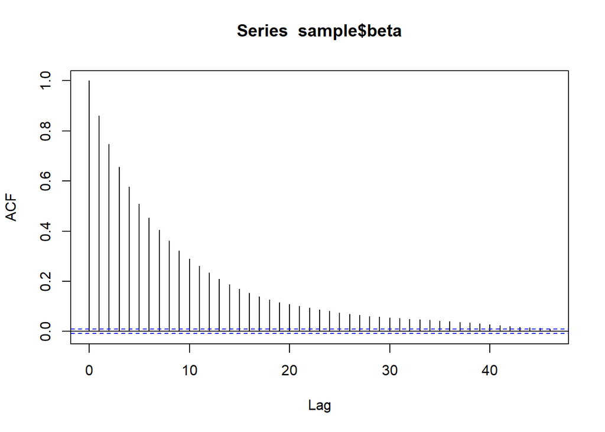

```r
acf(sample$beta)
```

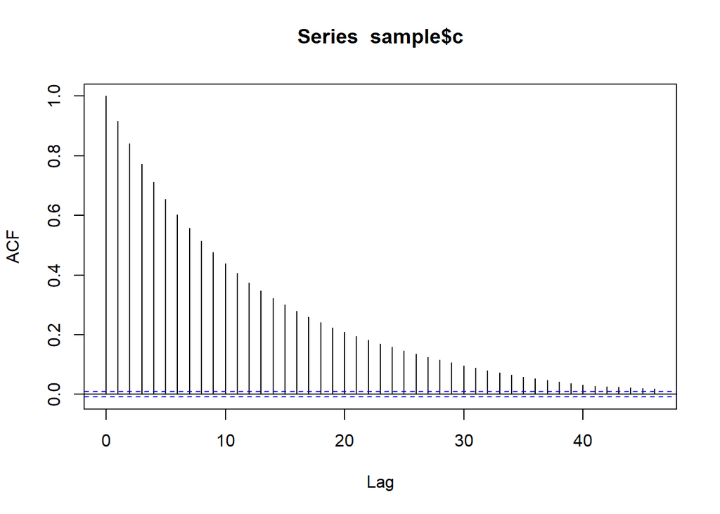

```r
acf(sample$c)
```

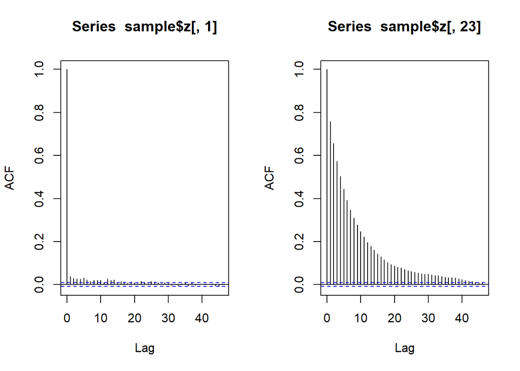

```r
par(mfrow = c(1,2))
acf(sample$z[,1]) # y == 0
acf(sample$z[,23]) # y == 1
```

#### d)

obtain 95% posterior confidence interval for $\beta$, as well as $P(\beta>0\mid \mathbf{y,x})$

```r
quantile(sample$beta, c(0.025,0.975))
```

```
##      2.5%     97.5%
## 0.1121733 0.6882838
```

```r
mean(sample$beta>0)
```

```
## [1] 0.99888
```

## Exercise 3

#### a)

obtain posterior samples of $\theta$ and $\Sigma$. Using sample mean and variance as prior.

```r
blue <- read.table("bluecrab.dat",col.names = c("y1","y2"))
orange <- read.table("orangecrab.dat", col.names = c("y1","y2"))
```

```r
ybar.1 <- apply(blue, 2, mean)
ybar.2 <- apply(orange, 2, mean)

prior.1 <- list(mu0 = ybar.1,
                lambda0 = as.matrix(t(blue-ybar.1)) %*% as.matrix(blue-ybar.1),
                nu0 = 4,
                S0 = as.matrix(t(blue-ybar.1)) %*% as.matrix(blue-ybar.1))
prior.2 <- prior.1 <- list(mu0 = ybar.2,
                lambda0 = as.matrix(t(orange-ybar.2)) %*% as.matrix(orange-ybar.2),
                nu0 = 4,
                S0 = as.matrix(t(orange-ybar.2)) %*% as.matrix(orange-ybar.2))
```

```r
gibbs_crab <- function(size, prior, data){
  #prior setup
  n <- nrow(data); p <- ncol(data)
  ybar <- apply(data, 2, mean)
  mu0 <- prior$mu0; lambda0 <- prior$lambda0
  nu0 <- prior$nu0; S0 <- prior$S0
  #first obs
  theta <- matrix(0,p,size)
  sigma <- array(1,dim = c(p,p,size)) ; sigma[,,1] <- diag(1,p)

  for(i in 2:size){
    #update mean
    lambda_n <- solve(n*solve(sigma[,,i-1]) + lambda0)
    mu_n <- lambda_n %*% (n*solve(sigma[,,i-1])%*%ybar + solve(lambda0)%*%mu0)
    theta[,i] <- MASS::mvrnorm(1, mu = mu_n, Sigma = lambda_n)

    #update variance
    nu_n <- prior$nu0 + n
    Sn <- S0 + t(data - ybar) %*% as.matrix(data - ybar)
    sigma[,,i] <- rWishart(1, nu_n, solve(Sn))
  }
  result <- list(theta = theta,
                 sigma = sigma)
  return(result)
}
blue.crab <- gibbs_crab(10000, prior.1, blue)
orange.crab <- gibbs_crab(10000, prior.2, orange)
```

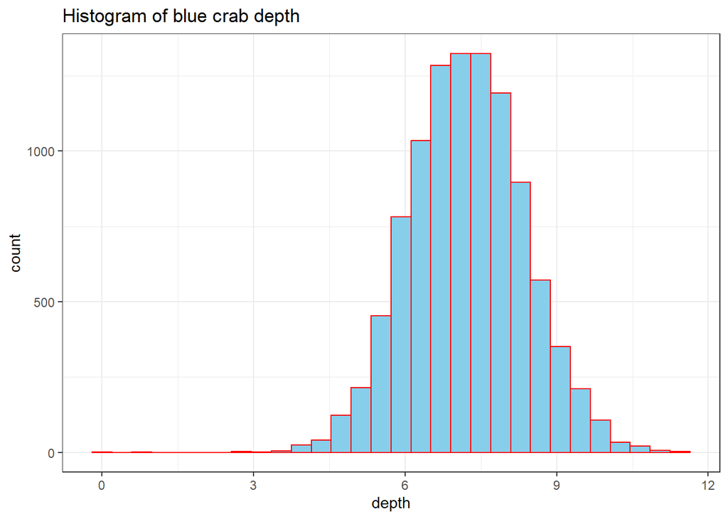

```r
ggplot() +
  geom_histogram(mapping = aes(x=blue.crab$theta[1,]),fill = "skyblue", col = "red") +
  labs(title = "Histogram of blue crab depth", x = "depth")
```

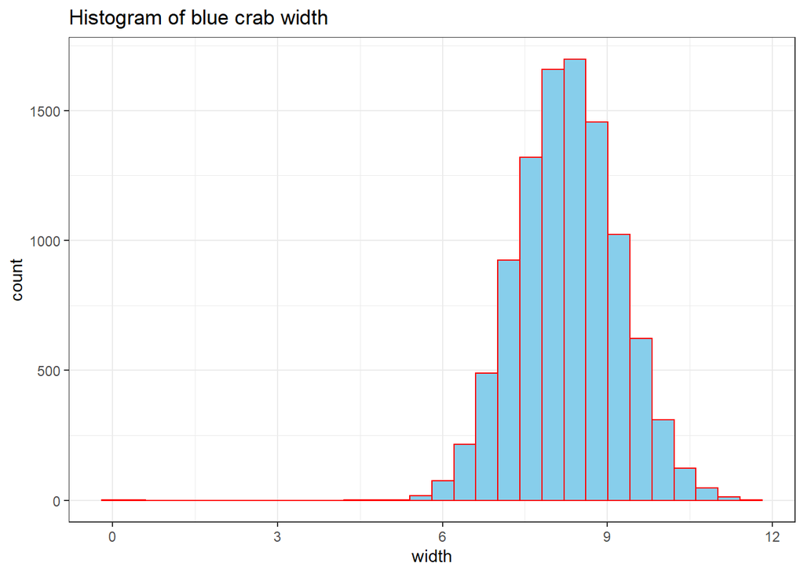

```r
ggplot() +
  geom_histogram(mapping = aes(x=blue.crab$theta[2,]),fill = "skyblue", col = "red") +
  labs(title = "Histogram of blue crab width", x = "width")
```

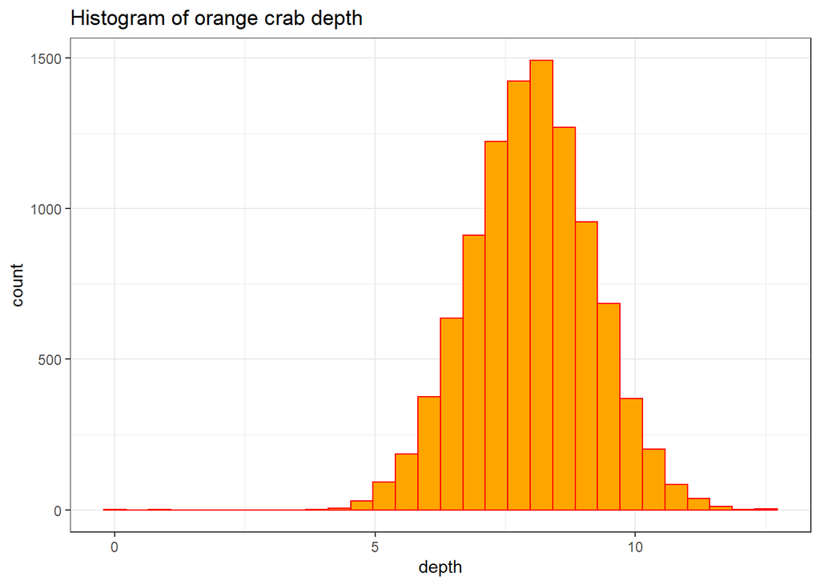

```r
ggplot() +
  geom_histogram(mapping = aes(x=orange.crab$theta[1,]),fill = "orange", col = "red") +
  labs(title = "Histogram of orange crab depth", x = "depth")
```

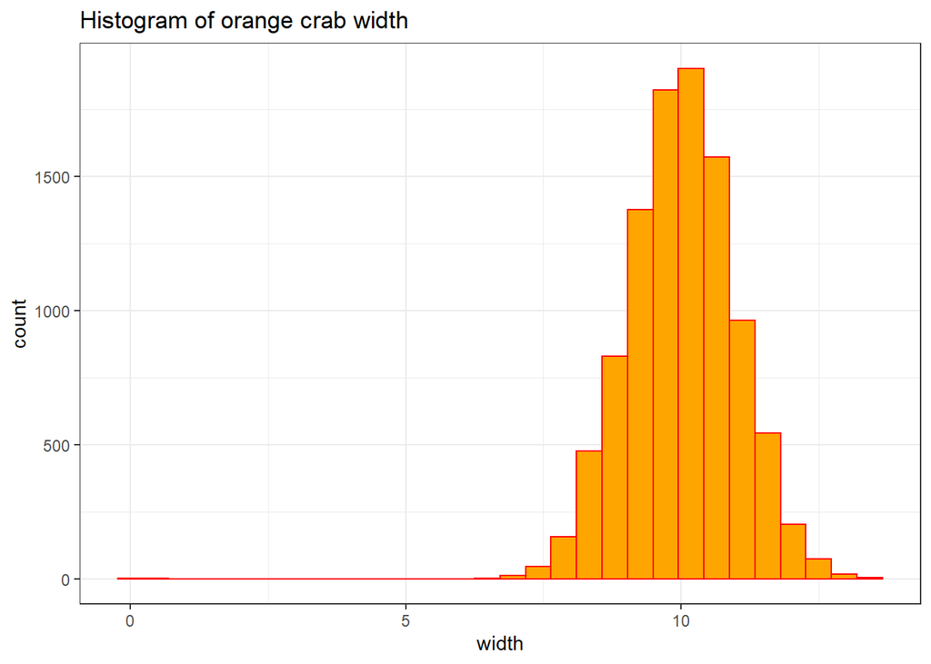

```r
ggplot() +
  geom_histogram(mapping = aes(x=orange.crab$theta[2,]),fill = "orange", col = "red") +
  labs(title = "Histogram of orange crab width", x = "width")
```

```r
diff.crab <- blue.crab$theta - orange.crab$theta

apply(diff.crab,1,function(x) mean(x<0))
```

```
## [1] 0.6871 0.9027
```

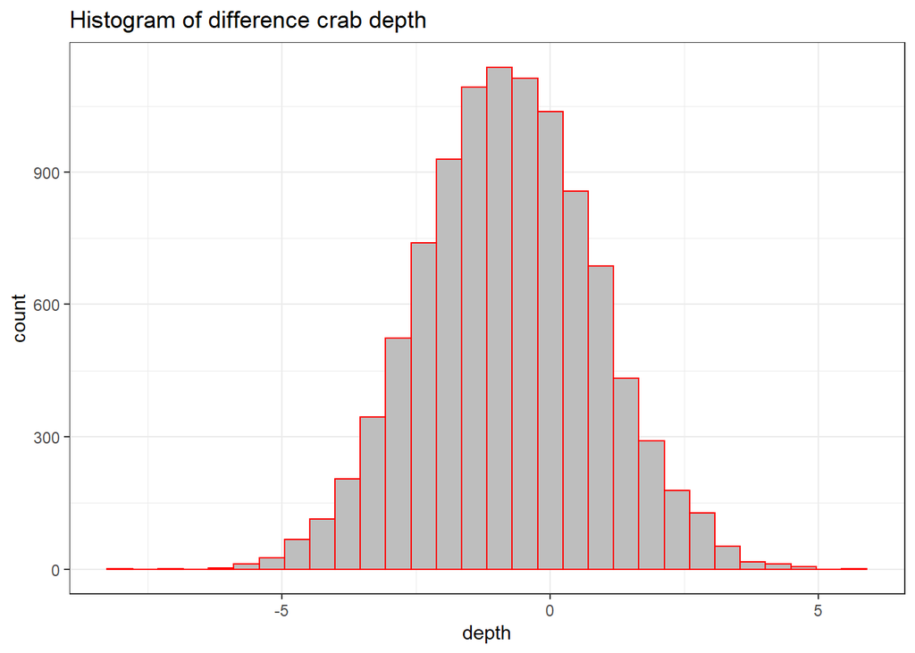

```r
ggplot() +
  geom_histogram(mapping = aes(x=diff.crab[1,]),fill = "gray", col = "red") +
  labs(title = "Histogram of difference crab depth", x = "depth")
```

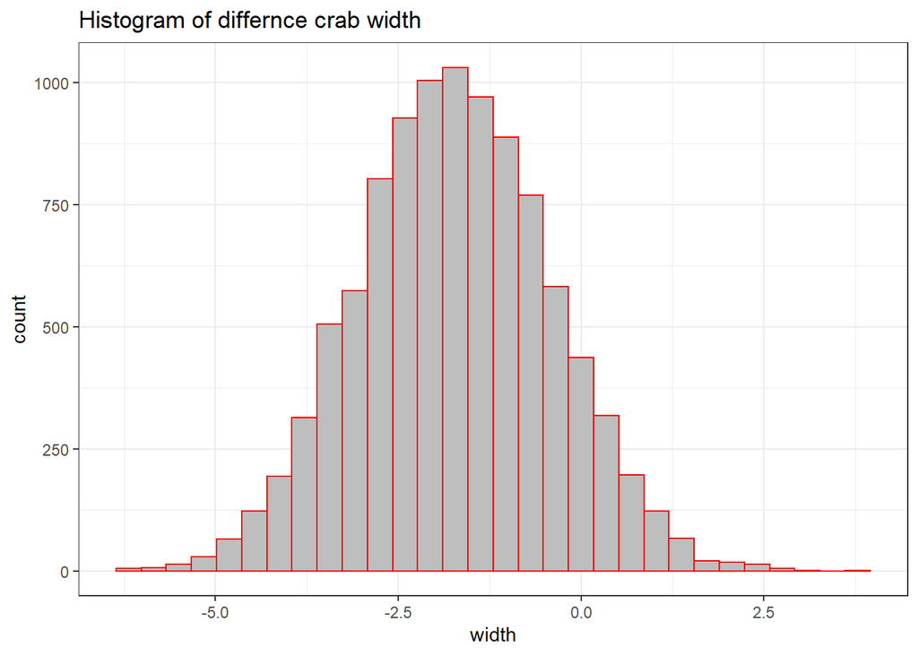

```r
ggplot() +
  geom_histogram(mapping = aes(x=diff.crab[2,]),fill = "gray", col = "red") +
  labs(title = "Histogram of differnce crab width", x = "width")
```

In both measure, orange crab is larger than blue crab on average. As an evidence, the predictive probability that difference between orange and blue crab in width and depth shows that 90% and 68% for each measure.

#### c)

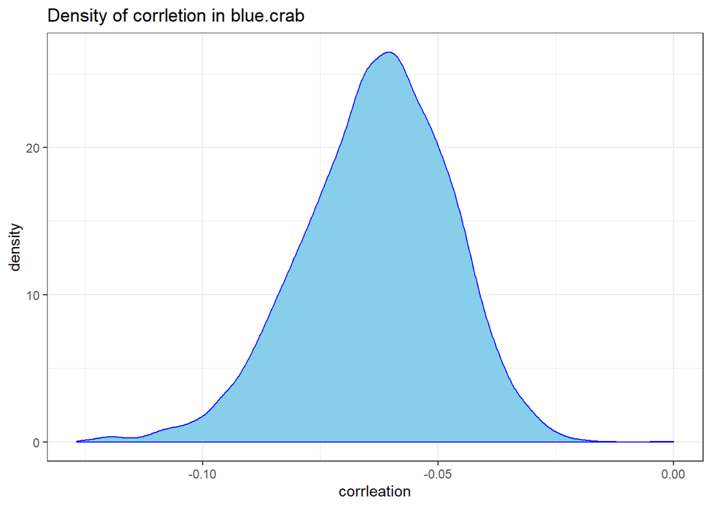

```r
blue.cor <- blue.crab$sigma[1,2,]
orange.cor <- orange.crab$sigma[1,2,]
ggplot() +
  geom_density(mapping = aes(x = blue.cor), col = "blue", fill = "skyblue") +
  labs(title = "Density of corrletion in blue.crab", x = "corrleation")
```

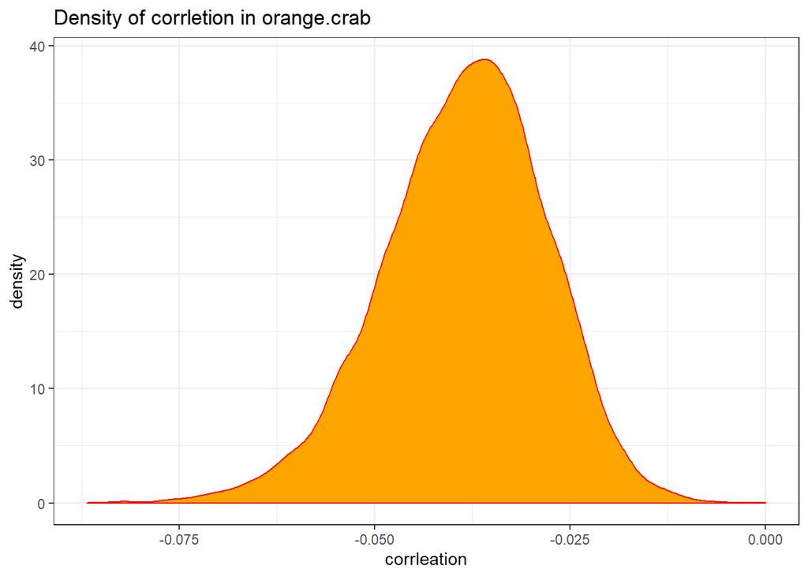

```r
ggplot() +
  geom_density(mapping = aes(x = orange.cor), col = "red", fill = "orange") +
  labs(title = "Density of corrletion in orange.crab", x = "corrleation")
```

```r
mean(blue.cor<orange.cor)
```

```
## [1] 0.9137
```

Density of two species’ correlation between both variables are showing difference. The density of correlation in orange crab is much more concentrated on center, whereas the density of blue crab is dispersed. Moreover, as we can see the result of $P(\rho_{blue} <\rho_{orange} \mid \mathbf{y_{blue},y_{orange}})$, the correlation of two variables in orange crab is larger than blue’s, although absolute value in blue crab is larger than orange crab.